# Problem Set #2

```r
# Loading libraries
library(tidyverse)
library(broom)
library(modelsummary)
library(marginaleffects)
library(gapminder)
library(juanr)
library(stargazer)
```

## Question 1

```r
# Make year a factor

view(childcare)
help(childcare)
childcare = childcare %>%
  mutate(year = factor(year, levels =
                         c ("2008", "2009", "2010", "2011", "2012",
                            "2013", "2014", "2015", "2016", "2017", "2018"))
  )

child_mod = lm(infant_price ~ poverty_rate + year + state, data = childcare)
modelsummary(child_mod,
  title = "Outcome: Cost of Childcare",
  stars = TRUE,
  gof_omit = "IC|Log|Adj|F|RMSE",
  coef_rename = c(
    "(Intercept)" = "Intercept",
    "poverty_rate" = "Poverty Rate",
    "year"  = "Year",
    "state"   = "State"
  ))
```

Outcome: Cost of Childcare

|  | (1) |
| --- | --- |
| Intercept | 115.523*** |
|  | (1.459) |
| Poverty Rate | -1.668*** |
|  | (0.040) |
| year2009 | 2.581* |
|  | (1.036) |
| year2010 | 5.864*** |
|  | (1.027) |
| year2011 | 10.079*** |
|  | (1.027) |
| year2012 | 14.488*** |
|  | (1.022) |
| year2013 | 19.926*** |
|  | (1.021) |
| year2014 | 23.301*** |
|  | (1.003) |
| year2015 | 25.231*** |
|  | (1.003) |
| year2016 | 26.680*** |
|  | (0.998) |
| year2017 | 30.017*** |
|  | (1.006) |
| year2018 | 32.885*** |
|  | (1.012) |
| stateAlaska | 104.523*** |
|  | (5.102) |
| stateArizona | 56.714*** |
|  | (2.529) |
| stateArkansas | -12.007*** |
|  | (1.875) |

[output cut: 92 more lines]

+ p < 0.1, * p < 0.05, ** p < 0.01, *** p < 0.001

```r
coef(child_mod)["poverty_rate"]
```

```
poverty_rate
   -1.667851
```

When holding for the year and state, when all else is the same, one increase increase in the rate of poverty for a county brings the cost of childcare down by about $1.67.

Using the fitted model, I will select the year 2012 in North Carolina while varying the poverty rate to see how this relationship holds.

```r
scenario = crossing(
  poverty_rate = seq(
    min(childcare$poverty_rate, na.rm = TRUE),
    max(childcare$poverty_rate, na.rm = TRUE)),

  state = "North Carolina",
  year = "2012"
  )


preds = augment(child_mod, newdata = scenario, se_fit = TRUE,
                interval = "confidence")
preds
```

```
# A tibble: 53 × 7
   poverty_rate state          year  .fitted .lower .upper .se.fit
          <int> <chr>          <chr>   <dbl>  <dbl>  <dbl>   <dbl>
 1            0 North Carolina 2012     173.   170.   176.    1.60
 2            1 North Carolina 2012     171.   168.   174.    1.59
 3            2 North Carolina 2012     170.   167.   173.    1.57
 4            3 North Carolina 2012     168.   165.   171.    1.56
 5            4 North Carolina 2012     166.   163.   169.    1.55
 6            5 North Carolina 2012     165.   162.   168.    1.54
 7            6 North Carolina 2012     163.   160.   166.    1.53
 8            7 North Carolina 2012     161.   158.   164.    1.52
 9            8 North Carolina 2012     160.   157.   163.    1.52
10            9 North Carolina 2012     158.   155.   161.    1.51
# ℹ 43 more rows
```

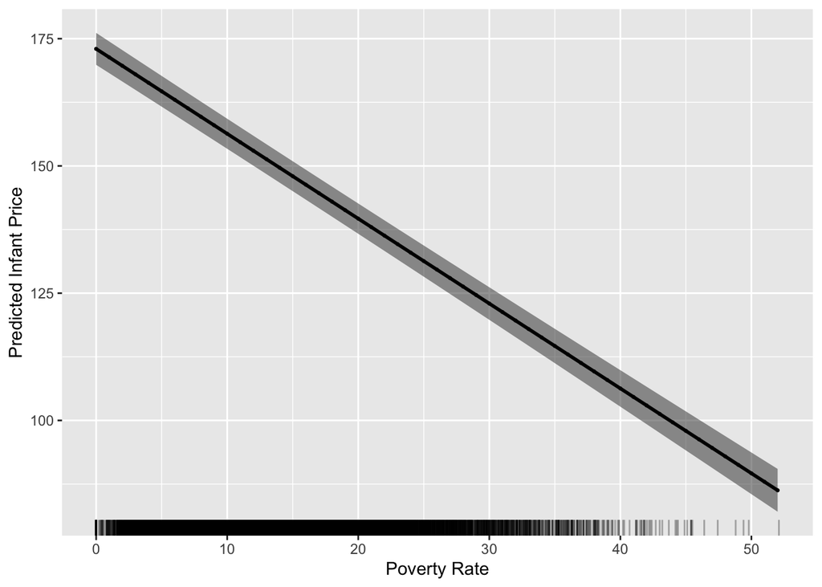

```r
# Visualize the marginal effect of income

ggplot(preds, aes(x = poverty_rate, y = .fitted)) +
  geom_point(size = 0.5) +
  geom_ribbon(aes(ymin = .lower, ymax = .upper), width = 0.2 , alpha = 0.5) +
  geom_line(linewidth = 1) +
  geom_rug(data = childcare, aes(x = poverty_rate),
           inherit.aes = FALSE, alpha = 0.3, sides = "b") +
  labs(
    x = "Poverty Rate",
    y = "Predicted Infant Price"
  )
```

Our plot corroborates what is found in our model estimate. As the rate in poverty increases by state county, the predicted infant price goes down.

```r
quad_child = lm(infant_price ~ poverty_rate + poverty_rate2 + year + state,
                data = mutate(childcare, poverty_rate2 = poverty_rate^2))

modelsummary(quad_child,
  title = "Outcome: Cost of Childcare",
  stars = TRUE,
  gof_omit = "IC|Log|Adj|F|RMSE",
  coef_rename = c(
    "(Intercept)" = "Intercept",
    "poverty_rate" = "Poverty Rate",
    "poverty_rate2" = "Poverty Rate^2",
    "year"  = "Year",
    "state"   = "State"
  ))
```

Outcome: Cost of Childcare

|  | (1) |
| --- | --- |
| Intercept | 140.883*** |
|  | (1.626) |
| Poverty Rate | -5.223*** |
|  | (0.116) |
| Poverty Rate^2 | 0.108*** |
|  | (0.003) |
| year2009 | 2.560* |
|  | (1.014) |
| year2010 | 6.062*** |
|  | (1.005) |
| year2011 | 10.533*** |
|  | (1.005) |
| year2012 | 15.277*** |
|  | (1.000) |
| year2013 | 20.901*** |
|  | (0.999) |
| year2014 | 24.251*** |
|  | (0.982) |
| year2015 | 25.953*** |
|  | (0.981) |
| year2016 | 27.156*** |
|  | (0.976) |
| year2017 | 30.104*** |
|  | (0.984) |
| year2018 | 32.744*** |
|  | (0.990) |
| stateAlaska | 93.586*** |
|  | (5.002) |
| stateArizona | 57.175*** |
|  | (2.474) |

[output cut: 94 more lines]

+ p < 0.1, * p < 0.05, ** p < 0.01, *** p < 0.001

```r
coef(quad_child)["poverty_rate2"]
```

```
poverty_rate2
    0.1082808
```

Within this model the effect of poverty rate on infant price depends on the current level of poverty. Poverty rate is no longer constant, so given the negative effect of poverty, as the poverty rate increases, childcare costs are projected to go down $5.22 until some point when poverty increases. After that point, the effect becomes less negative.

```r
scenario = crossing(
  poverty_rate = seq(
    min(childcare$poverty_rate, na.rm = TRUE),
    max(childcare$poverty_rate, na.rm = TRUE),
    length.out = 100
  ),
  state = "North Carolina",
  year = "2012") %>%
  mutate(poverty_rate2 = poverty_rate^2)


preds2 = augment(quad_child, newdata = scenario, se_fit = TRUE,
                interval = "confidence")
preds2
```

```
# A tibble: 100 × 8
   poverty_rate state          year  poverty_rate2 .fitted .lower .upper .se.fit
          <dbl> <chr>          <chr>         <dbl>   <dbl>  <dbl>  <dbl>   <dbl>
 1        0     North Carolina 2012          0        200.   197.   203.    1.77
 2        0.526 North Carolina 2012          0.277    197.   194.   201.    1.74
 3        1.05  North Carolina 2012          1.11     195.   191.   198.    1.71
 4        1.58  North Carolina 2012          2.49     192.   189.   195.    1.68
 5        2.11  North Carolina 2012          4.43     189.   186.   193.    1.66
 6        2.63  North Carolina 2012          6.92     187.   184.   190.    1.63
 7        3.16  North Carolina 2012          9.97     185.   181.   188.    1.61
 8        3.68  North Carolina 2012         13.6      182.   179.   185.    1.59
 9        4.21  North Carolina 2012         17.7      180.   177.   183.    1.57
10        4.74  North Carolina 2012         22.4      178.   175.   181.    1.56
# ℹ 90 more rows
```

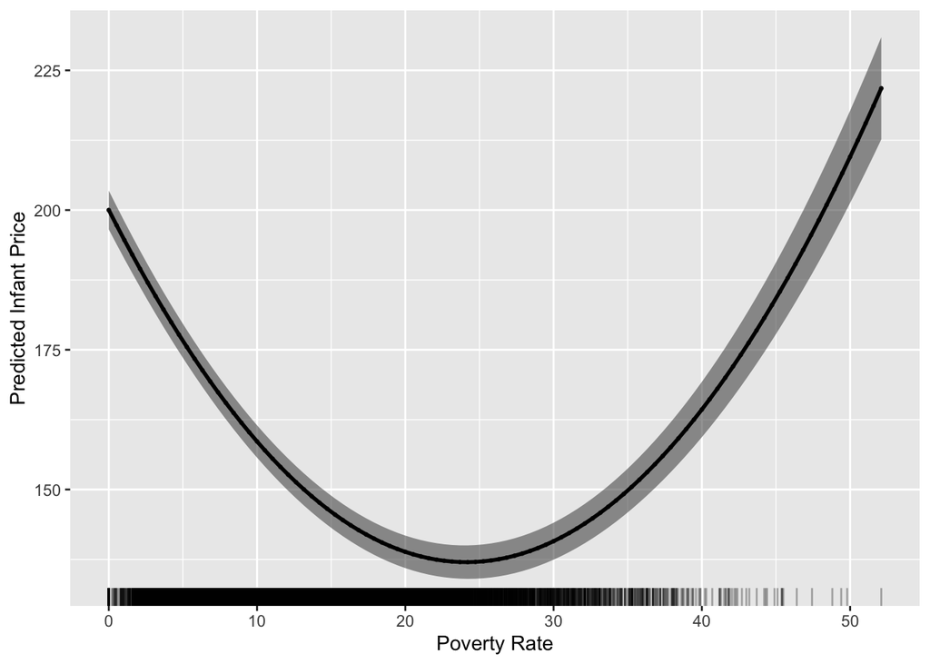

```r
# Visualize the marginal effect of income

ggplot(preds2, aes(x = poverty_rate, y = .fitted)) +
  geom_point(size = 0.5) +
  geom_ribbon(aes(ymin = .lower, ymax = .upper), width = 0.2 , alpha = 0.5) +
  geom_line(linewidth = 1) +
  geom_rug(data = childcare, aes(x = poverty_rate),
           inherit.aes = FALSE, alpha = 0.3, sides = "b") +
  labs(
    x = "Poverty Rate",
    y = "Predicted Infant Price"
  )
```

This U-turn around might have something to do with how each state policy allocates funding for childcare in proportion to their constituents’ earnings.

My new model is: infant price =

$\beta _{0} + \beta _{1} * povertyrate + \beta_{2} * poverty rate^{2}$

Marginal effects =

```r
pov_seq = seq(
  min(childcare$poverty_rate, na.rm = TRUE),
  max(childcare$poverty_rate, na.rm = TRUE),
  length.out = 100
)

# Extracting the coefficients

b1 = coef(quad_child)["poverty_rate"]
b2 = coef(quad_child)["poverty_rate2"]

# Use sequencing from min to max

marginal_effect = b1 + 2 * b2 * pov_seq
```

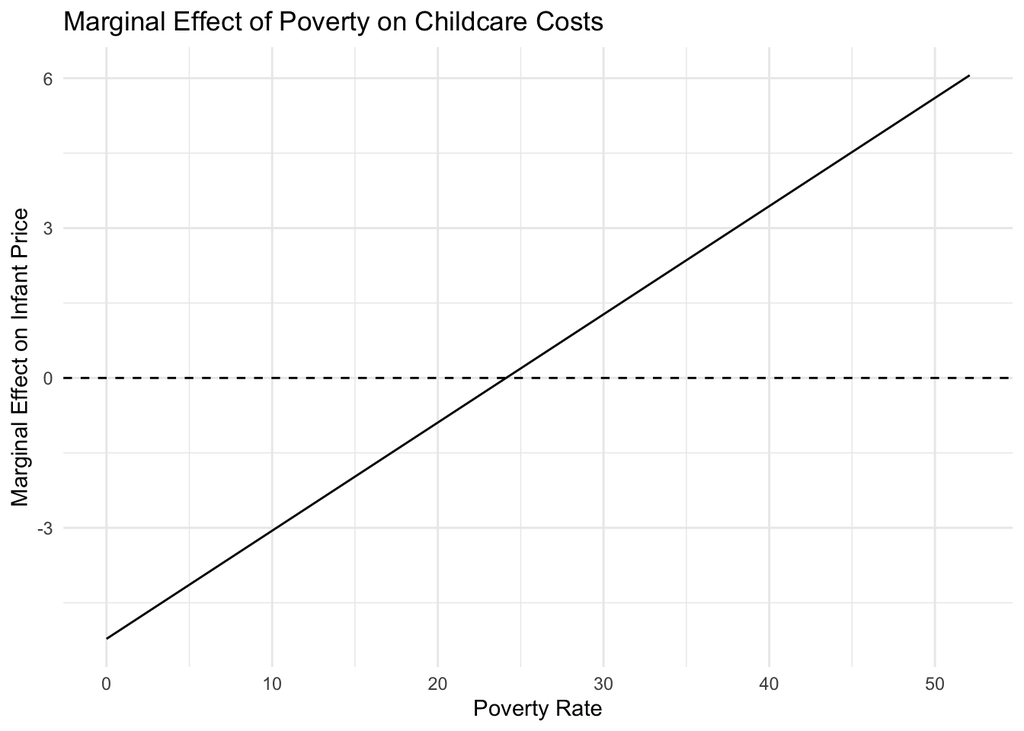

```r
effects_data = data.frame(
  poverty_rate = pov_seq,
  marginal_effect = marginal_effect
)

ggplot(effects_data, aes(x = poverty_rate, y = marginal_effect)) +
  geom_line() +
  geom_hline(yintercept = 0, linetype = "dashed") +
  labs(
    x = "Poverty Rate",
    y = "Marginal Effect on Infant Price",
    title = "Marginal Effect of Poverty on Childcare Costs"
  ) +
  theme_minimal()
```

When the rate of poverty is low, the effect on infant price is a negative one, suggesting that there are areas who pay less for childcare given their rate of poverty. However, as the rate of poverty increases, that effect becomes less strong and then turns positive. Perhaps, these counties have to pay a price that is disproportionate to their earnings and their local legislation has yet to account for it.

## Question 2

```r
view(therm)
therm = therm %>%
  mutate(Republican = if_else(party_id %in% c("Republican"), 1, 0)) %>%
  mutate(education = case_when(
    educ == "No HS" ~ 0,
    educ == "High school graduate" ~ 1,
    educ == "Some college" ~ 2,
    educ == "2-year" ~ 3,
    educ == "4-year" ~ 4,
    educ == "Post-grad" ~ 5
  ))

therm_mod = lm(ft_immig ~ Republican + education, data = therm)
modelsummary(therm_mod,
  title = "Outcome: Feelings towards Immigrants",
  stars = TRUE,
  gof_omit = "IC|Log|Adj|F|RMSE",
  coef_rename = c(
    "(Intercept)" = "Intercept",
    "Republican" = "Republican",
    "education"  = "Education"
  ))
```

Outcome: Feelings towards Immigrants

|  | (1) |
| --- | --- |
| Intercept | 57.128*** |
|  | (0.868) |
| Republican | -15.569*** |
|  | (0.829) |
| Education | 3.140*** |
|  | (0.250) |
| Num.Obs. | 4792 |
| R2 | 0.103 |

+ p < 0.1, * p < 0.05, ** p < 0.01, *** p < 0.001

```r
coef(therm_mod)["Republican"]
```

```
Republican
 -15.56893
```

When holding for education level, given that all else is the same, a respondent being a republican decreases their warm feelings towards immigrants by about 15.6 on the thermometer scale.

What happens if we add an interaction between education and republican? Surely education attainment is distributed a certain way across partisan lines.

```r
# Interaction between republican and education

therm_mod2 = lm(ft_immig ~ Republican + education + Republican:education, data = therm)
modelsummary(therm_mod,
  title = "Outcome: Feelings towards Immigrants",
  stars = TRUE,
  gof_omit = "IC|Log|Adj|F|RMSE",
  coef_rename = c(
    "(Intercept)" = "Intercept",
    "Republican" = "Republican",
    "education"  = "Education",
    "Republican:education" = "Republican x Education"
  ))
```

Outcome: Feelings towards Immigrants

|  | (1) |
| --- | --- |
| Intercept | 57.128*** |
|  | (0.868) |
| Republican | -15.569*** |
|  | (0.829) |
| Education | 3.140*** |
|  | (0.250) |
| Num.Obs. | 4792 |
| R2 | 0.103 |

+ p < 0.1, * p < 0.05, ** p < 0.01, *** p < 0.001

```r
coef(therm_mod2)["Republican:education"]
```

```
Republican:education
          -0.6395538
```

Marginal effects formula =

$\frac{\partial\hat{Y}}{\partial republican} = \beta_{1} + \beta_{3} * education$

This means that the effect of being a republican towards your feelings on immigrants now depends on education. Since our coefficient is negative, a higher education should make the effect more negative.

```r
b1 = coef(therm_mod2)["Republican"]
b3 = coef(therm_mod2)["Republican:education"]

educ_vals = 1:8
marginal_effects = b1 + b3 * educ_vals

data.frame(educ = educ_vals, ME = marginal_effects)
```

```
  educ        ME
1    1 -14.40276
2    2 -15.04232
3    3 -15.68187
4    4 -16.32143
5    5 -16.96098
6    6 -17.60053
7    7 -18.24009
8    8 -18.87964
```

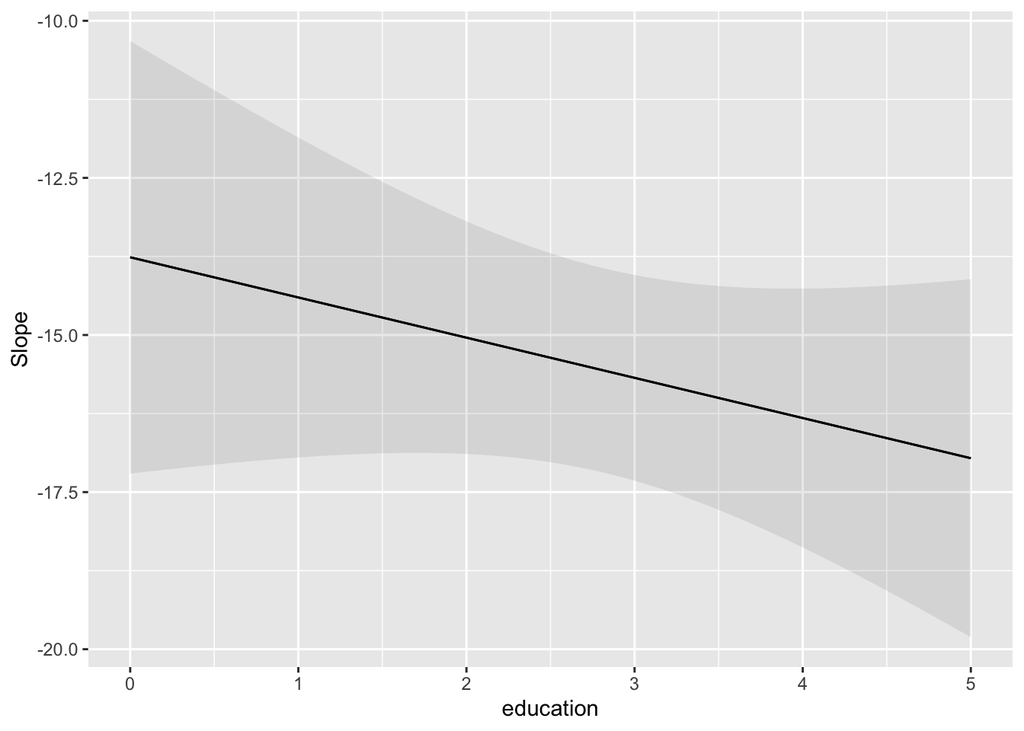

```r
library(marginaleffects)

slopes = slopes(
  therm_mod2,
  variables = "Republican",
  newdata = datagrid(educ_num = 1:8)
)

plot_slopes(
  therm_mod2,
  variables = "Republican",
  condition = "education"
)
```

From our marginal effects results and slopes plot, as education increases, Republicans feel colder toward immigrants.

## Question 3

```r
view(bonica)
help(bonica)
# Filter out missing values
bonica = bonica %>%
  filter(
    !is.na(num_distinct_donors),
    !is.na(total_receipts),
    num_distinct_donors != 0,
    total_receipts != 0
  )
```

Within a constant linear model, more unique donors should more than likely yield a positive effect on the amount of fundraising. However, if donors pledge or give a very high amount, it may limit the level of giving that other donors contribute if they are aware that congressional candidates are receiving larger donations. It would make sense to log the number of donors given that each donation may matter a little less than the last given the magnitude of the donation.

```r
log_mod = lm(total_receipts ~ log(num_distinct_donors) + cycle + party,
             data = bonica)

modelsummary(log_mod,
  title = "Outcome: Number of donors on total receipts ",
  stars = TRUE,
  gof_omit = "IC|Log|Adj|F|RMSE",
  coef_rename = c(
    "(Intercept)" = "Intercept",
    "log(num_distinct_donors)" = "log(Number of Donors)",
    "cycle"  = "Election Year",
    "party" = "Party"
  ))
```

Outcome: Number of donors on total receipts

|  | (1) |
| --- | --- |
| Intercept | -142024364.280*** |
|  | (29315621.660) |
| log(Number of Donors) | 475990.278*** |
|  | (14391.630) |
| Election Year | 69851.353*** |
|  | (14540.225) |
| partyI | 542766.590** |
|  | (193735.624) |
| partyR | 35262.897 |
|  | (75927.766) |
| Num.Obs. | 5405 |
| R2 | 0.173 |

+ p < 0.1, * p < 0.05, ** p < 0.01, *** p < 0.001

```r
scenario2 = crossing(
  num_distinct_donors = seq(
    min(bonica$num_distinct_donors, na.rm = TRUE),
    max(bonica$num_distinct_donors, na.rm = TRUE),
    length.out = 100
  ),
  cycle = median(bonica$cycle),
  party = "R"
)


preds3 = augment(log_mod, newdata = scenario2, se_fit = TRUE,
                interval = "confidence")
preds3
```

```
# A tibble: 100 × 7
   num_distinct_donors cycle party   .fitted    .lower   .upper .se.fit
                 <dbl> <dbl> <chr>     <dbl>     <dbl>    <dbl>   <dbl>
 1                  1   2016 R     -1168774. -1344653. -992895.  89716.
 2               2039.  2016 R      2458428.  2326488. 2590369.  67303.
 3               4077.  2016 R      2788243.  2644147. 2932339.  73503.
 4               6116.  2016 R      2981202.  2829277. 3133126.  77496.
 5               8154.  2016 R      3118116.  2960369. 3275863.  80466.
 6              10192.  2016 R      3224319.  3061920. 3386717.  82839.
 7              12230.  2016 R      3311094.  3144814. 3477374.  84819.
 8              14269.  2016 R      3384463.  3214849. 3554077.  86520.
 9              16307.  2016 R      3448018.  3275480. 3620557.  88012.
10              18345.  2016 R      3504078.  3328934. 3679223.  89341.
# ℹ 90 more rows
```

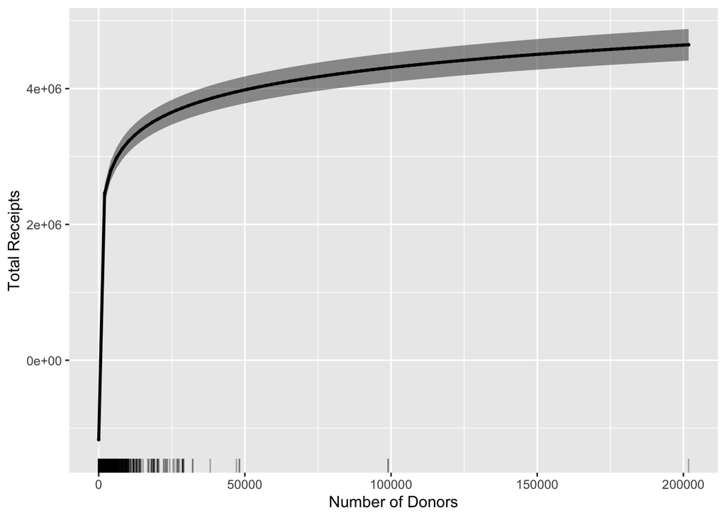

```r
# Visualize the marginal effect of income

ggplot(preds3, aes(x = num_distinct_donors, y = .fitted)) +
  geom_point(size = 0.5) +
  geom_ribbon(aes(ymin = .lower, ymax = .upper), width = 0.2 , alpha = 0.5) +
  geom_line(linewidth = 1) +
  geom_rug(data = bonica, aes(x = num_distinct_donors),
           inherit.aes = FALSE, alpha = 0.3, sides = "b") +
  labs(
    x = "Number of Donors",
    y = "Total Receipts"
  )
```

There is some sort of growth rate for the amount of donors a candidate may have and the total dollars raised. The growth surges for only a few amount of donors until it plateaus. This may corroborate the theory that when constituents are aware of the amount of support a candidate has, the amount the give drops off.

## Question 4

I will use the landfill dataset from the last problem set and analyze the same X-Y relationship between the amount of wells (Y) and the waste in place (X). I will control again for current status of the landfills.

```r
library(readxl)

Landfills = read_xlsx("landfilllmopdata.xlsx", sheet = 2) %>%
  janitor::clean_names() %>%
  tidyr::drop_na()

Landfills
```

```
# A tibble: 31 × 42
   ghgrp_id landfill_id landfill_name      state landfill_alias physical_address
      <dbl>       <dbl> <chr>              <chr> <chr>          <chr>
 1  1006026        2052 City of Fort Smit… AR    Fort Smith Sa… 5900 Commerce R…
 2  1007736         106 Cummings Road Lan… CA    City Garbage … 5775 Cummings R…
 3  1002107          62 Frank R. Bowerman… CA    Bee Canyon SLF 11002 Bee Canyo…
 4  1003918         338 Mid-Valley Sanita… CA    Fontana Refus… 2390 N. Alder A…
 5  1002320         232 Olinda Alpha SLF   CA    Olinda SLF     1942 N. Valenci…
 6  1004692         270 San Timoteo Solid… CA    San Timoteo S… 31 Refuse Road
 7  1002901         430 Bee Ridge LF       FL    Bee Ridge Roa… 8350 Bee Ridge …
 8  1000349         431 Osceola Landfill   FL    Seminole Coun… 1930 E. Osceola…
 9  1007898         409 Springhill Region… FL    Springhill No… 4945 W State Hw…
10  1001909         398 Zemel Road Landfi… FL    Charlotte Cou… 29751 Zemel Road
# ℹ 21 more rows
# ℹ 36 more variables: city <chr>, county <chr>, zip_code <chr>,
#   latitude <dbl>, longitude <dbl>, composting <chr>, ownership_type <chr>,
#   landfill_owner_organization_s <chr>, landfill_operator_organization <chr>,
#   year_landfill_opened <dbl>, landfill_closure_year <dbl>,
#   current_landfill_status <chr>, design_landfill_area_acres <dbl>,
#   current_landfill_area_acres <dbl>, design_landfill_depth_feet <dbl>, …
```

```r
new_landfills = Landfills %>% select(landfill_name ,
                                     state ,
                                     waste_in_place_tons ,
                                     current_landfill_status ,
                                     number_of_wells) %>%
  mutate(waste_in_place_thousand_tons = waste_in_place_tons/1000)


new_landfills$current_landfill_status =
  ifelse(new_landfills$current_landfill_status == "Open", 1, 0)
```

```r
set.seed(123)

sample1 = new_landfills %>% slice_sample(n = 50)
sample2 = new_landfills %>% slice_sample(n = 50)
```

```r
# Sample 1
m1_s1 = lm(number_of_wells ~
             waste_in_place_thousand_tons + current_landfill_status, data = sample1)

m2_s1 = lm(number_of_wells ~
             poly(waste_in_place_thousand_tons, 2) + current_landfill_status, data = sample1)

m3_s1 = lm(number_of_wells ~
             poly(waste_in_place_thousand_tons, 3) + current_landfill_status, data = sample1)

m4_s1 = lm(number_of_wells ~
             poly(waste_in_place_thousand_tons, 4) + current_landfill_status, data = sample1)

# Sample 2
m1_s2 = lm(number_of_wells ~
             waste_in_place_thousand_tons + current_landfill_status, data = sample2)

m2_s2 = lm(number_of_wells ~
             poly(waste_in_place_thousand_tons, 2) + current_landfill_status, data = sample2)

m3_s2 = lm(number_of_wells ~
             poly(waste_in_place_thousand_tons, 3) + current_landfill_status, data = sample2)

m4_s2 = lm(number_of_wells ~
             poly(waste_in_place_thousand_tons, 4) + current_landfill_status, data = sample2)
```

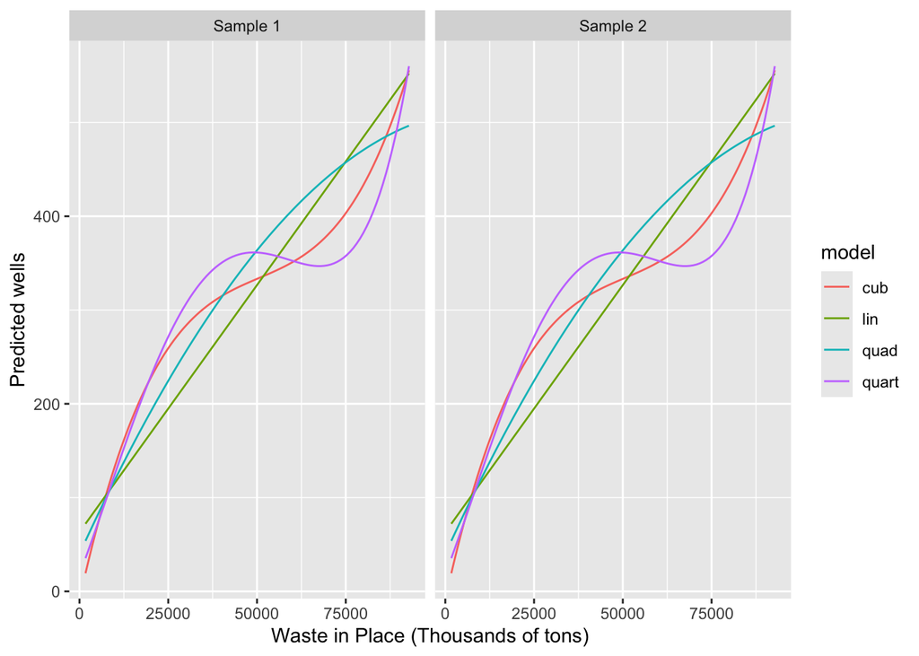

```r
waste_grid = data.frame(
  waste_in_place_thousand_tons = seq(min(new_landfills$waste_in_place_thousand_tons),
              max(new_landfills$waste_in_place_thousand_tons), length.out = 100),
  current_landfill_status = mean(new_landfills$current_landfill_status)
)

waste_grid$lin_s1  = predict(m1_s1, newdata = waste_grid)
waste_grid$quad_s1 = predict(m2_s1, newdata = waste_grid)
waste_grid$cub_s1  = predict(m3_s1, newdata = waste_grid)
waste_grid$quart_s1 = predict(m4_s1, newdata = waste_grid)

waste_grid$lin_s2 = predict(m1_s2, newdata = waste_grid)
waste_grid$quad_s2 = predict(m2_s2, newdata = waste_grid)
waste_grid$cub_s2 = predict(m3_s2, newdata = waste_grid)
waste_grid$quart_s2 = predict(m4_s2, newdata = waste_grid)

waste_plot = waste_grid %>%
  pivot_longer(cols = -c(waste_in_place_thousand_tons, current_landfill_status),
               names_to = "model",
               values_to = "pred") %>%
  mutate(sample = ifelse(grepl("s1", model), "Sample 1", "Sample 2"),
         model = gsub("_s[12]", "", model))

ggplot(waste_plot, aes(x = waste_in_place_thousand_tons, y = pred, color = model)) +
  geom_line() +
  facet_wrap(~ sample) +
  labs(x = "Waste in Place (Thousands of tons)" , y = "Predicted wells")
```

## Question 5

The goal with running a simulation, when repeating it 500 times, is to generate fake data from the DGP, run a regression and store the coefficients.

```r
set.seed(1234) #So that the results are easy to replicate

simulations = data.frame(run = 1:500 ,
                         beta_x = NA,
                         p_x = NA,
                         beta_int = NA,
                         p_int = NA
) # Creating a table to store coefficients, p-values, and interaction beta and p


for (i in 1:500) {

  N = 150

  # Generating data
  x = rnorm(N, 0, 1) # Continuous variable
  z = rbinom(N, 1, 0.5) # Binary variable
  epsilon = rnorm(N, 0, 5) # Noise?

  y = 10 + 3 * x + 2 * z + 1.5 * (x * z) + epsilon

  # Running regression
  model = lm(y ~ x * z)

  # Extract results
  coefs = summary(model)$coefficients

  simulations$beta_x[i] = coefs["x", "Estimate"]
  simulations$p_x[i] = coefs["x", "Pr(>|t|)"]

  simulations$beta_int[i] = coefs["x:z", "Estimate"]
  simulations$p_int[i] = coefs["x:z", "Pr(>|t|)"]
}
```

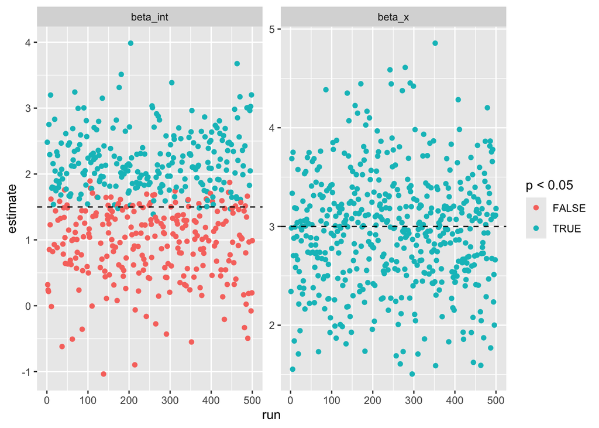

```r
simulation_plot = simulations %>%
  mutate(sig_x = p_x < 0.05, #Reshaping significance for plot
         sig_int = p_int < 0.05) %>%
  pivot_longer(
    cols = c(beta_x, beta_int),
    names_to = "term",
    values_to = "estimate"
  ) %>%
  mutate(sig = ifelse(term == "beta_x", sig_x, sig_int),
         true_value = ifelse(term == "beta_x", 3, 1.5))

ggplot(simulation_plot, aes(x = run, y = estimate, color = sig)) +
  geom_point() +
  facet_wrap(~ term, scales = "free_y") +
  geom_hline(aes(yintercept = true_value), linetype = "dashed") +
  labs(color = "p < 0.05")
```

```r
mean(simulations$p_x < 0.05)
```

```
[1] 1
```

```r
mean(simulations$p_int < 0.05)
```

```
[1] 0.488
```

However, as we see here the main effect has a higher detection rate than the interaction effect. Even though both effects are present in the DGP and within our visualization, the interaction has a larger standard error. This demonstrates that current studies are under-powered to detect interaction effects. A larger sample size may be able to counteract this.